# Initial Regression Model with Race and HH Conditions

Jon Geiger, Noel Goodwin, Abigail Joppa

2022-06-08

```r
library(tidyverse)
library(tidylog)
library(openintro)
library(leaps)
library(ggthemes)
theme_set(theme_clean())
source("../scripts/prune_race_variables.R")
```

# Purpose

The goal of this analysis is to fit a simple linear regression model to predict average high school district graduation rate based on household conditions and racial composition of the surrounding area.

# Data Import and Cleaning

```r
grad <- read_csv("../data/grad.csv")
hh   <- read_csv("../data/hh.csv") %>%
    select(-ends_with("MOE"))
```

```
##
## select: dropped 6 variables (SP_MOE, HHVJ_MOE, CC_MOE, nci_MOE, CD_MOE, …)
```

```r
race <- read_csv("../data/race.csv") %>%
    prune_and_predom()
```

```
##
## select: dropped 59 variables (geo_id, dist, year, total_pop_est, total_pop_moe, …)
##
## mutate: converted 'leaid' from double to integer (0 new NA)
##
## select: dropped one variable (leaid)
##
## mutate: new variable 'predom_race' (factor) with 5 unique values and 0% NA
##
## select: dropped 6 variables (pct_hisp_latino, pct_white, pct_black, pct_native, pct_asian, …)
```

```r
data <- grad %>%
    left_join(hh, by = c("leaid" = "leaid")) %>%
    left_join(race, by = c("leaid" = "leaid")) %>%
    select(-region, -predom_race)
```

```
## left_join: added 11 columns (state, dist, children, pct_pov, pct_SP, …)
##            > rows only in x    1,900
##            > rows only in y  ( 2,550)
##            > matched rows     10,763
##            >                 ========
##            > rows total       12,663
## left_join: added 7 columns (predom_race, pct_hisp_latino, pct_white, pct_black, pct_native, …)
##            > rows only in x    2,462
##            > rows only in y  ( 1,709)
##            > matched rows     10,201
##            >                 ========
##            > rows total       12,663
## select: dropped 2 variables (region, predom_race)
```

```r
glimpse(data)
```

```
## Rows: 12,663
## Columns: 18
## $ leaid           <dbl> 100005, 100006, 100007, 100008, 100011, 100012, 100013…
## $ grad_rate_midpt <dbl> 90.62127, 88.86380, 92.01013, 95.81859, 90.77311, 86.4…
## $ state           <chr> "Alabama", "Alabama", "Alabama", "Alabama", "Alabama",…
## $ dist            <chr> "Albertville City School District", "Marshall County S…
## $ children        <dbl> 4591, 8299, 15397, 9416, 2324, 1644, 4476, 3064, 1425,…
## $ pct_pov         <dbl> 0.30053842, 0.26622182, 0.07259553, 0.08298157, 0.1688…
## $ pct_SP          <dbl> 0.3529261, 0.2951967, 0.2083155, 0.1783983, 0.2743837,…
## $ pct_HHVJ        <dbl> 0.3265352, 0.2348667, 0.2921655, 0.2093061, 0.3043552,…
## $ pct_CC          <dbl> 0.047664441, 0.026383169, 0.015484872, 0.016083051, 0.…
## $ pct_NCI         <dbl> 0.22147135, 0.14248565, 0.03168848, 0.10363837, 0.2376…
## $ pct_CD          <dbl> 0.01807885, 0.04349922, 0.03877379, 0.05777400, 0.0800…
## $ pct_CLI         <dbl> 0.1736005247, 0.0386793576, 0.0441644490, 0.0042480882…
## $ pct_hisp_latino <dbl> 44.6, 24.3, 12.9, 7.8, 9.1, 10.8, 1.8, 11.8, 1.7, 1.0,…
## $ pct_white       <dbl> 49.4, 70.0, 56.7, 64.1, 65.5, 86.9, 82.6, 43.2, 63.3, …
## $ pct_black       <dbl> 3.5, 1.7, 23.1, 15.0, 24.6, 0.0, 6.7, 41.7, 33.0, 77.7…
## $ pct_native      <dbl> 0.0, 0.2, 0.0, 0.1, 0.8, 0.0, 0.0, 0.0, 0.0, 0.0, 0.3,…
## $ pct_asian       <dbl> 0.8, 0.8, 4.8, 5.5, 0.0, 0.0, 2.6, 2.4, 1.0, 0.2, 0.7,…
## $ pct_PI          <dbl> 0, 0, 0, 0, 0, 0, 0, 0, 0, 0, 0, 0, 0, 0, 0, 0, 0, 0, …
```

We can notice immediately that our original dataset variables such as `pct_pov` and `pct_SP`, are proportions ranging from 0 to 1. We can also notice that the columns representing our racial data such as `pct_hisp_latino` and `pct_white`, are percentages ranging from 0 to 100. In order to run a regression model, we will standardize these predictors and make all fo them range from 0 to 100. This is so that we can interpret a value of “1” as “1%” rather than 100%.

```r
data_standardized <- data %>%
    mutate(
        across(.cols = pct_pov:pct_CLI,
               .fns = ~ . * 100)
    )
```

```
## mutate: changed 10,752 values (85%) of 'pct_pov' (0 new NA)
```

```
##         changed 10,725 values (85%) of 'pct_SP' (0 new NA)
```

```
##         changed 10,756 values (85%) of 'pct_HHVJ' (0 new NA)
```

```
##         changed 10,276 values (81%) of 'pct_CC' (0 new NA)
```

```
##         changed 10,608 values (84%) of 'pct_NCI' (0 new NA)
```

```
##         changed 10,409 values (82%) of 'pct_CD' (0 new NA)
```

```
##         changed 5,075 values (40%) of 'pct_CLI' (0 new NA)
```

Now that the variables are standardized, let’s check out what a simple linear regression model with all variables as predictors would look like.

# Initial HH Conditions Analysis

We will first construct a simple linear regression model using all household conditions as predictors.

```r
full_df <- data_standardized %>%
    select(pct_pov:pct_PI, grad_rate_midpt) %>%
    na.omit()
```

```
## select: dropped 4 variables (leaid, state, dist, children)
```

```r
hh_df <- full_df %>%
    select(pct_pov:pct_CLI, grad_rate_midpt)
```

```
## select: dropped 6 variables (pct_hisp_latino, pct_white, pct_black, pct_native, pct_asian, …)
```

```r
race_df <- full_df %>%
    select(pct_hisp_latino:pct_PI, grad_rate_midpt)
```

```
## select: dropped 7 variables (pct_pov, pct_SP, pct_HHVJ, pct_CC, pct_NCI, …)
```

```r
hh_model <- lm(grad_rate_midpt ~ ., data = hh_df)
race_model <- lm(grad_rate_midpt ~ ., data = race_df)
full_model <- lm(grad_rate_midpt ~ ., data = full_df)

summary(hh_model)
```

```
##
## Call:
## lm(formula = grad_rate_midpt ~ ., data = hh_df)
##
## Residuals:
##     Min      1Q  Median      3Q     Max
## -73.642  -3.230   1.381   4.470  23.745
##
## Coefficients:
##              Estimate Std. Error t value Pr(>|t|)
## (Intercept) 95.295719   0.387741 245.771  < 2e-16 ***
## pct_pov     -0.140192   0.012211 -11.481  < 2e-16 ***
## pct_SP      -0.128985   0.007249 -17.793  < 2e-16 ***
## pct_HHVJ    -0.062998   0.014420  -4.369 1.26e-05 ***
## pct_CC      -0.399606   0.028942 -13.807  < 2e-16 ***
## pct_NCI     -0.014030   0.008569  -1.637  0.10159
## pct_CD      -0.041546   0.021244  -1.956  0.05053 .
## pct_CLI      0.057739   0.019129   3.018  0.00255 **
## ---
## Signif. codes:  0 '***' 0.001 '**' 0.01 '*' 0.05 '.' 0.1 ' ' 1
##
## Residual standard error: 7.126 on 10193 degrees of freedom
## Multiple R-squared:  0.1811, Adjusted R-squared:  0.1805
## F-statistic: 321.9 on 7 and 10193 DF,  p-value: < 2.2e-16
```

```r
summary(race_model)
```

```
##
## Call:
## lm(formula = grad_rate_midpt ~ ., data = race_df)
##
## Residuals:
##     Min      1Q  Median      3Q     Max
## -71.464  -3.267   1.444   4.788  24.271
##
## Coefficients:
##                 Estimate Std. Error t value Pr(>|t|)
## (Intercept)     67.98072    1.62965  41.715  < 2e-16 ***
## pct_hisp_latino  0.15221    0.01698   8.964  < 2e-16 ***
## pct_white        0.20780    0.01695  12.261  < 2e-16 ***
## pct_black        0.08658    0.01778   4.869 1.14e-06 ***
## pct_native      -0.04875    0.01957  -2.491  0.01275 *
## pct_asian        0.42143    0.02435  17.310  < 2e-16 ***
## pct_PI          -0.60659    0.18706  -3.243  0.00119 **
## ---
## Signif. codes:  0 '***' 0.001 '**' 0.01 '*' 0.05 '.' 0.1 ' ' 1
##
## Residual standard error: 7.109 on 10194 degrees of freedom
## Multiple R-squared:  0.1847, Adjusted R-squared:  0.1842
## F-statistic:   385 on 6 and 10194 DF,  p-value: < 2.2e-16
```

```r
summary(full_model)
```

```
##
## Call:
## lm(formula = grad_rate_midpt ~ ., data = full_df)
##
## Residuals:
##     Min      1Q  Median      3Q     Max
## -72.874  -3.065   1.361   4.395  22.342
##
## Coefficients:
##                  Estimate Std. Error t value Pr(>|t|)
## (Intercept)     77.397473   1.694660  45.671  < 2e-16 ***
## pct_pov         -0.130124   0.012245 -10.626  < 2e-16 ***
## pct_SP          -0.076844   0.007840  -9.801  < 2e-16 ***
## pct_HHVJ        -0.071285   0.014064  -5.068 4.08e-07 ***
## pct_CC          -0.164292   0.033814  -4.859 1.20e-06 ***
## pct_NCI          0.015406   0.008514   1.809 0.070412 .
## pct_CD          -0.069184   0.020942  -3.304 0.000958 ***
## pct_CLI         -0.096282   0.022501  -4.279 1.89e-05 ***
## pct_hisp_latino  0.169099   0.017266   9.794  < 2e-16 ***
## pct_white        0.170447   0.016735  10.185  < 2e-16 ***
## pct_black        0.127181   0.017664   7.200 6.45e-13 ***
## pct_native      -0.013247   0.020182  -0.656 0.511596
## pct_asian        0.303210   0.024836  12.209  < 2e-16 ***
## pct_PI          -0.518837   0.182115  -2.849 0.004395 **
## ---
## Signif. codes:  0 '***' 0.001 '**' 0.01 '*' 0.05 '.' 0.1 ' ' 1
##
## Residual standard error: 6.903 on 10187 degrees of freedom
## Multiple R-squared:  0.232,  Adjusted R-squared:  0.231
## F-statistic: 236.7 on 13 and 10187 DF,  p-value: < 2.2e-16
```

We can immediately notice that some of these predictors are extremely significant in terms of being able to predict graduation rate. Factors such as `pct_pov`, `pct_SP`, `pct_hisp_latino`, `pct_white`, and `pct_asian` are all significant with p-values less than 2e-16.

We can run a quick ANOVA comparison between the model with just household conditions and the model with all predictors, in order to see if the model with race data provides a statistically significant improvement in the model.

```r
anova(hh_model, full_model)
```

```
## Analysis of Variance Table
##
## Model 1: grad_rate_midpt ~ pct_pov + pct_SP + pct_HHVJ + pct_CC + pct_NCI +
##     pct_CD + pct_CLI
## Model 2: grad_rate_midpt ~ pct_pov + pct_SP + pct_HHVJ + pct_CC + pct_NCI +
##     pct_CD + pct_CLI + pct_hisp_latino + pct_white + pct_black +
##     pct_native + pct_asian + pct_PI
##   Res.Df    RSS Df Sum of Sq      F    Pr(>F)
## 1  10193 517534
## 2  10187 485357  6     32177 112.56 < 2.2e-16 ***
## ---
## Signif. codes:  0 '***' 0.001 '**' 0.01 '*' 0.05 '.' 0.1 ' ' 1
```

```r
anova(race_model, full_model)
```

```
## Analysis of Variance Table
##
## Model 1: grad_rate_midpt ~ pct_hisp_latino + pct_white + pct_black + pct_native +
##     pct_asian + pct_PI
## Model 2: grad_rate_midpt ~ pct_pov + pct_SP + pct_HHVJ + pct_CC + pct_NCI +
##     pct_CD + pct_CLI + pct_hisp_latino + pct_white + pct_black +
##     pct_native + pct_asian + pct_PI
##   Res.Df    RSS Df Sum of Sq      F    Pr(>F)
## 1  10194 515220
## 2  10187 485357  7     29863 89.542 < 2.2e-16 ***
## ---
## Signif. codes:  0 '***' 0.001 '**' 0.01 '*' 0.05 '.' 0.1 ' ' 1
```

We can see that for both the race-only and the hh-conditions-only models, including the other set of data does provide a significant decrease in the model RSS.

# Best Subset Analysis

In order to choose the best set of predictors, we will perform best subset analysis, utilizing the `regsubsets()` function from the `leaps` library.

```r
fit_full <- regsubsets(grad_rate_midpt ~ .,
                       data = full_df,
                       nvmax = ncol(full_df) - 1)
reg_summary <- summary(fit_full)
reg_summary
```

```
## Subset selection object
## Call: regsubsets.formula(grad_rate_midpt ~ ., data = full_df, nvmax = ncol(full_df) -
##     1)
## 13 Variables  (and intercept)
##                 Forced in Forced out
## pct_pov             FALSE      FALSE
## pct_SP              FALSE      FALSE
## pct_HHVJ            FALSE      FALSE
## pct_CC              FALSE      FALSE
## pct_NCI             FALSE      FALSE
## pct_CD              FALSE      FALSE
## pct_CLI             FALSE      FALSE
## pct_hisp_latino     FALSE      FALSE
## pct_white           FALSE      FALSE
## pct_black           FALSE      FALSE
## pct_native          FALSE      FALSE
## pct_asian           FALSE      FALSE
## pct_PI              FALSE      FALSE
## 1 subsets of each size up to 13
## Selection Algorithm: exhaustive
##           pct_pov pct_SP pct_HHVJ pct_CC pct_NCI pct_CD pct_CLI pct_hisp_latino
## 1  ( 1 )  " "     "*"    " "      " "    " "     " "    " "     " "
## 2  ( 1 )  "*"     " "    " "      " "    " "     " "    " "     " "
## 3  ( 1 )  "*"     "*"    " "      " "    " "     " "    " "     " "
## 4  ( 1 )  "*"     "*"    " "      " "    " "     " "    " "     " "
## 5  ( 1 )  "*"     "*"    " "      " "    " "     " "    " "     " "
## 6  ( 1 )  "*"     "*"    " "      " "    " "     " "    " "     "*"
## 7  ( 1 )  "*"     "*"    " "      "*"    " "     " "    " "     "*"
## 8  ( 1 )  "*"     "*"    "*"      "*"    " "     " "    " "     "*"
## 9  ( 1 )  "*"     "*"    "*"      "*"    " "     " "    "*"     "*"
## 10  ( 1 ) "*"     "*"    "*"      "*"    " "     "*"    "*"     "*"
## 11  ( 1 ) "*"     "*"    "*"      "*"    " "     "*"    "*"     "*"
## 12  ( 1 ) "*"     "*"    "*"      "*"    "*"     "*"    "*"     "*"
## 13  ( 1 ) "*"     "*"    "*"      "*"    "*"     "*"    "*"     "*"
##           pct_white pct_black pct_native pct_asian pct_PI
## 1  ( 1 )  " "       " "       " "        " "       " "
## 2  ( 1 )  " "       " "       "*"        " "       " "
## 3  ( 1 )  " "       " "       "*"        " "       " "
## 4  ( 1 )  "*"       " "       "*"        " "       " "
## 5  ( 1 )  "*"       " "       "*"        "*"       " "
## 6  ( 1 )  "*"       "*"       " "        "*"       " "
## 7  ( 1 )  "*"       "*"       " "        "*"       " "
## 8  ( 1 )  "*"       "*"       " "        "*"       " "
## 9  ( 1 )  "*"       "*"       " "        "*"       " "
## 10  ( 1 ) "*"       "*"       " "        "*"       " "
## 11  ( 1 ) "*"       "*"       " "        "*"       "*"
## 12  ( 1 ) "*"       "*"       " "        "*"       "*"
## 13  ( 1 ) "*"       "*"       "*"        "*"       "*"
```

In this output, one row represents one model. We fit thirteen models, each of which is the “best model” for that number of predictors.

We can immediately notice something interesting: The best one-variable model uses `pct_SP`, or percent of single-parent households, as a predictor. The best two-variable model, however, does not use `pct_SP`, but rather `pct_pov` and `pct_native` as predictors. The best three-variable model utilizes all three of these predictors.

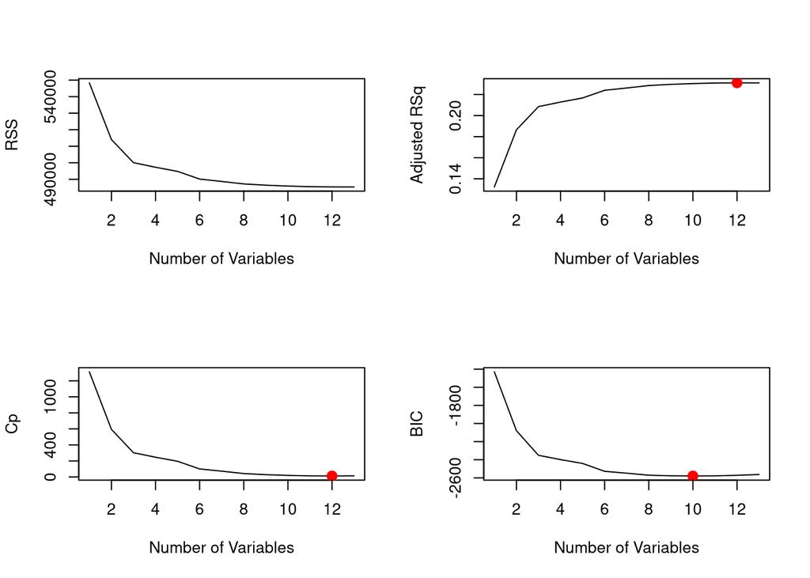

```r
par(mfrow = c(2, 2))
plot(reg_summary$rss, xlab = "Number of Variables",
     ylab = "RSS", type = "l")
plot(reg_summary$adjr2, xlab = "Number of Variables",
     ylab = "Adjusted RSq", type = "l")
points(which.max(reg_summary$adjr2), reg_summary$adjr2[which.max(reg_summary$adjr2)], col = "red", cex = 2, pch = 20)
plot(reg_summary$cp, xlab = "Number of Variables",
     ylab = "Cp", type = "l")
points(which.min(reg_summary$cp), reg_summary$cp[which.min(reg_summary$cp)], col = "red", cex = 2, pch = 20)
plot(reg_summary$bic, xlab = "Number of Variables",
     ylab = "BIC", type = "l")
points (which.min(reg_summary$bic), reg_summary$bic[which.min(reg_summary$bic)], col = "red", cex = 2, pch = 20)
```

We can look more into, say, the Bayesian Information Criterion:

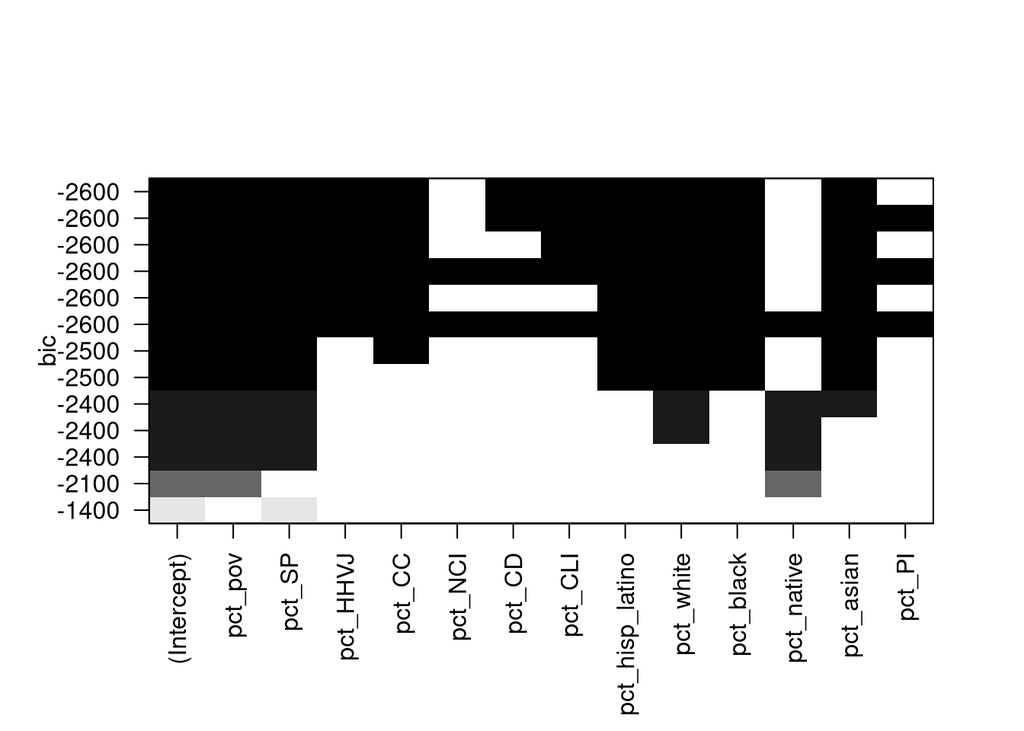

```r
plot(fit_full, scale = "bic")
```

To do:

- Assess whether variables such as `pct_native` should be considered in the model
- Use Training/Test/CV sets to avoid overfitting
- Check for multicollinearity
- Lasso regression to adjust for multicollinearity